# prediction_XER_pctIMP_OE

C. Emi Fergus

2023-11-03

## % Impervious surface in watershed riparian buffer

There are only nine sites in the Xeric ecoregion with % impervious surface in stream buffer > 5%. Most NRSA sites have less than 1% impervious surface in the riparian buffer.

But for those nine sites, we want to see how reducing % impervious surface would improve stream condition.

For sites with impervious surface in riparian buffer, will create scenarios where impervious surface is reduced.

## Examine Predicted vs Observed relationship for sites with impervious surface

Based on coefficients from path analysis model, estimated what O/E values would be using the dataset the model was trained on. We can compare predicted and observed values to see how well the model fit.

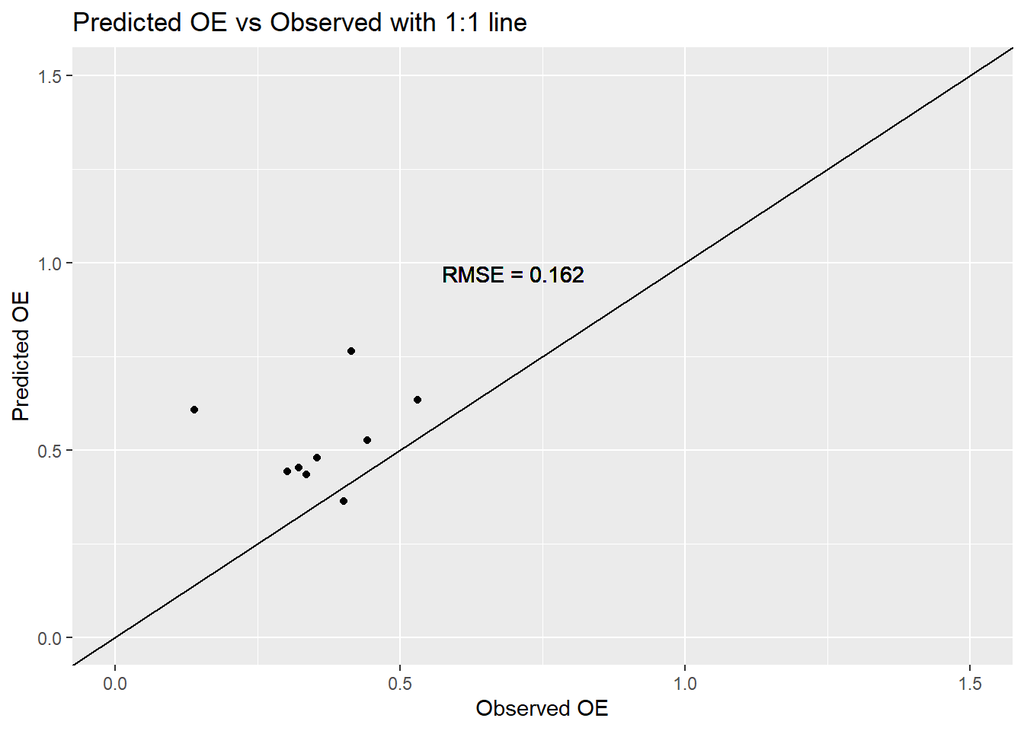

The RMSE is 0.16, indicating that average distance between the predicted O/E and observed O/E is 0.16 units. This difference seems like it would be problematic because a 16% loss in taxa richness might be important to the ecosystem.

## SCENARIO % IMPERVIOUS SURFACE

Reduce impervious surface for sites with values >5% Scenario 1: Reduce by 0% Scenario 2: Reduce by 5% (X% - 5%) Scenario 3: Reduce impervious surface by 50%

Bug O/E ~ 1.18 + 0.06(LRBS_use) + -0.14(L_NTL) + -0.08(L_SULF) + 0.05(LOE_Qbkf_cl) + 0.04(dam) + 0.12(Specific strm pwr)

```
##      Min.   1st Qu.    Median      Mean   3rd Qu.      Max.
## 0.0002644 0.0083559 0.0132344 0.0256902 0.0416460 0.0846003
```

```
##    Min. 1st Qu.  Median    Mean 3rd Qu.    Max.
## 0.01454 0.02492 0.02876 0.03443 0.04573 0.06625
```

Density distributions of predicted values under % Impervious surface scenarios

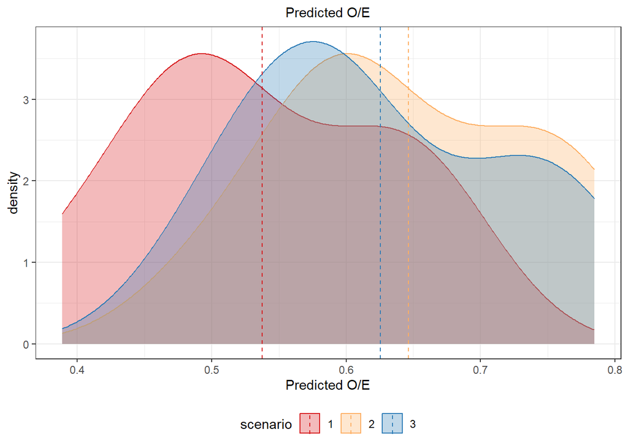

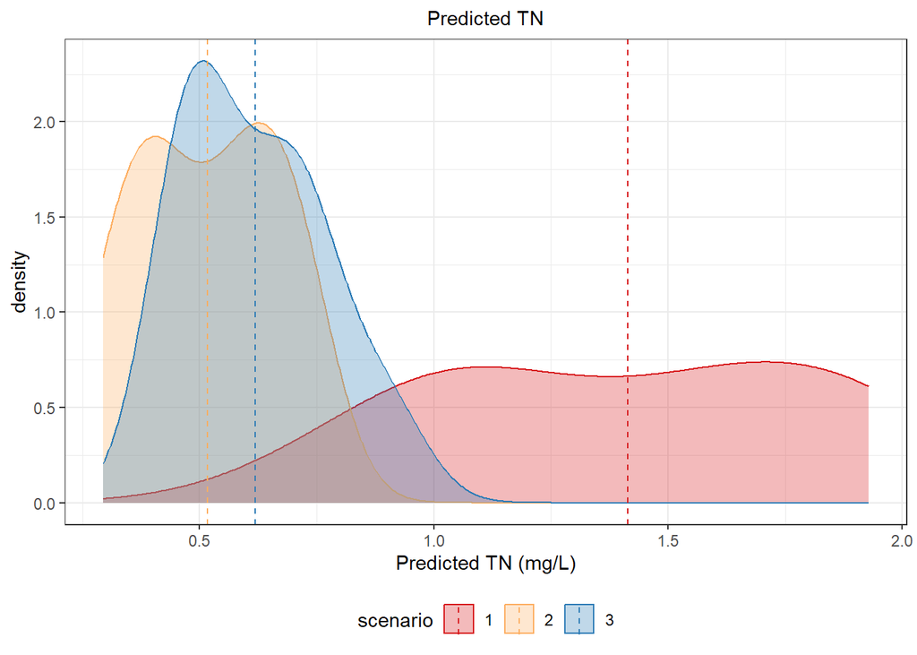

## SUBSET BY SITES WHERE IMPERVIOUS SURFACE CHANGED (Sites w/%IMPV > 5%)

## Calculate mean O/E by scenario

Mean Predicted Bug O/E

| scenario | mean_OE |
| --- | --- |
| 1 | 0.538 |
| 2 | 0.646 |
| 3 | 0.625 |

Boxplots of predicted O/E distributions

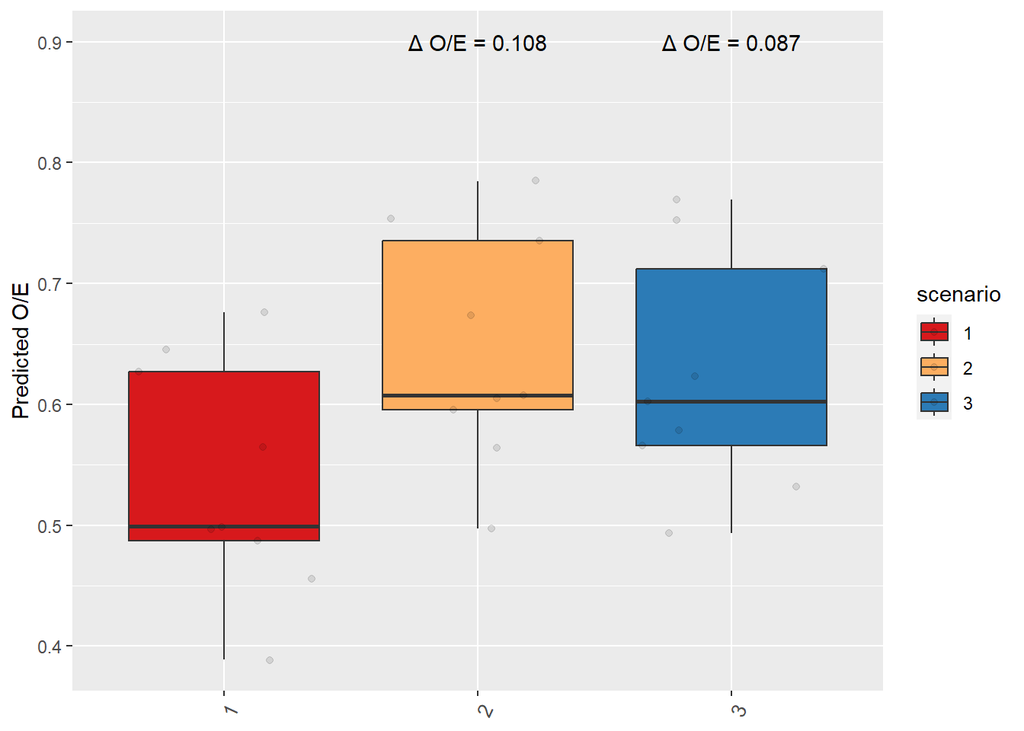

## Population estimates

See Dumelle et al. 2023 for tips using spsurvey package

```
##        Type Subpopulation  Indicator nResp  Estimate   StdError MarginofError
## 1 All_Sites     All Sites oe.predict     9 0.5380441 0.01533489    0.03005583
##    LCB95Pct UCB95Pct
## 1 0.5079883   0.5681
```

```
##        Type Subpopulation  Indicator nResp  Estimate   StdError MarginofError
## 1 All_Sites     All Sites oe.predict     9 0.6465108 0.01533489    0.03005583
##   LCB95Pct  UCB95Pct
## 1 0.616455 0.6765667
```

```
##        Type Subpopulation  Indicator nResp  Estimate   StdError MarginofError
## 1 All_Sites     All Sites oe.predict     9 0.6246931 0.01664385    0.03262135
##    LCB95Pct  UCB95Pct
## 1 0.5920718 0.6573145
```

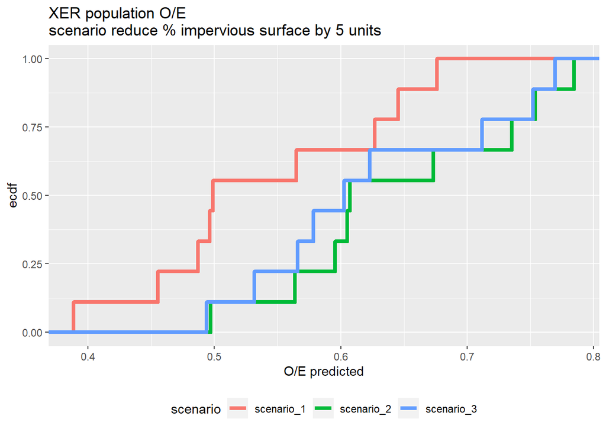

Estimate population of Xeric sites in % impervious surface classes

```
##
## <5% impervious >5% impervious
##            207              9
```

```
##        Type Subpopulation  Indicator       Category nResp Estimate.P StdError.P
## 1 All_Sites     All Sites impv_class <5% impervious   207  94.298045   1.872841
## 2 All_Sites     All Sites impv_class >5% impervious     9   5.701955   1.872841
## 3 All_Sites     All Sites impv_class          Total   216 100.000000   0.000000
##   MarginofError.P LCB95Pct.P UCB95Pct.P Estimate.U StdError.U MarginofError.U
## 1          3.6707  90.627345  97.968746  44671.903  2058.2847        4034.164
## 2          3.6707   2.031254   9.372655   2701.192   914.0951        1791.593
## 3          0.0000 100.000000 100.000000  47373.095  2122.9417        4160.889
##   LCB95Pct.U UCB95Pct.U
## 1  40637.739  48706.067
## 2    909.599   4492.786
## 3  43212.206  51533.985
```

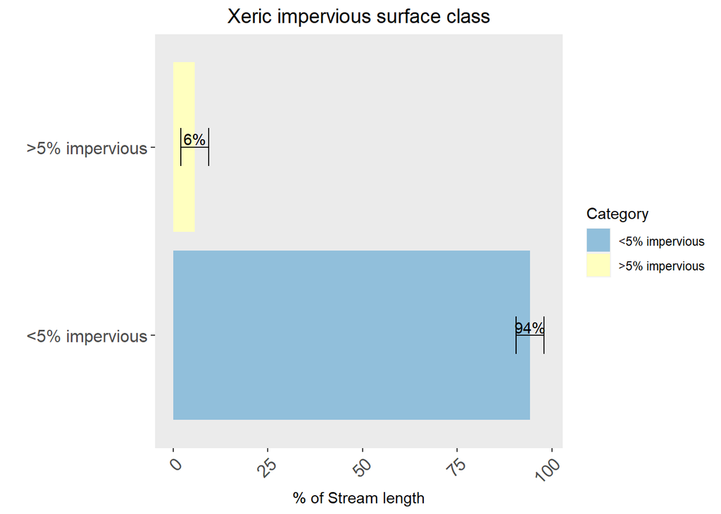